# Homework - CIs

# 1 MVP

Now we’ll go back to CI creation in the normal fashion. We’ll take the ames data from the CIs lab earlier today and regard it now as a sample, we won’t be drawing any smaller samples from within it. This is the usual situation in an analysis: you use all the data available to you!

```r
library(tidyverse)
library(janitor)
```

### Task 1.

Load the data again, clean_names(), and re-familiarise yourself with it

```r
ames <- clean_names(read_csv("data/ames.csv"))


skim(ames)
```

[output not shown]

### Task 2.

Investigate the distribution of lot_area. Is the distribution roughly normal? If not, what problems do you find? * a massive outlier.

```r
ames %>%
  summarise(range_lot_area = range(lot_area))
```

| range_lot_area |
| --- |
| 1300 |
| 215245 |

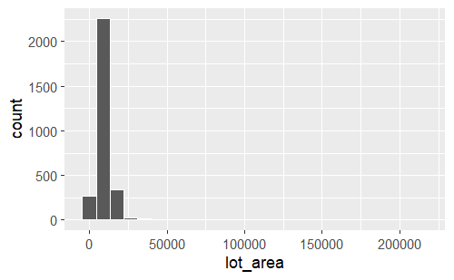

```r
ames %>%
  ggplot(aes(x = lot_area)) +
  geom_histogram(col = "white", bins = 25)
```

### Task 3.

Compute and visualise a bootstrap sampling distribution for the mean(lot_area) of the sold houses.

```r
sample_200 <- ames %>%
  rep_sample_n(size = 200, reps = 1)

summary_sample_200 <- sample_200 %>%
  ungroup() %>%
  summarise(
    mean_lot_area = mean(lot_area)
  )
summary_sample_200
```

| mean_lot_area |
| --- |
| 9770.45 |

```r
summary_popn <- ames %>%
  summarise(
    popn_mean_lot_area = mean(lot_area)
  )
summary_popn
```

| popn_mean_lot_area |
| --- |
| 10147.92 |

```r
bootstrap_resample_200 <- sample_200 %>%
  rep_sample_n(size = 200, replace = TRUE, reps = 5000) %>%
  summarise(
    mean_lot_area = mean(lot_area)
  )
```

[output not shown]

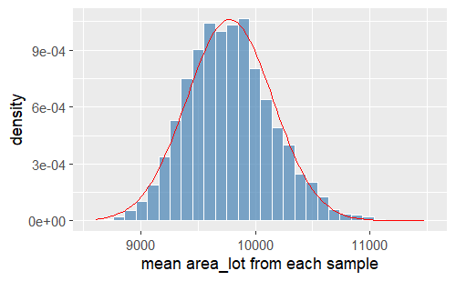

```r
bootstrap_resample_200 %>%
  ggplot(aes(x = mean_lot_area)) +
  geom_histogram(aes(y = ..density..), col = "white", fill = "steel blue", alpha = 0.7) +
  labs(x = "mean area_lot from each sample") +
    stat_function(
    fun = dnorm,
    args = list(
      mean = mean(bootstrap_resample_200$mean_lot_area),
      sd = sd(bootstrap_resample_200$mean_lot_area)
    ),
    col = "red"
  )
```

### Task 4.

Use your bootstrap distribution to calculate a 95% CI for mean(lot_area), and visualise it on the distribution

```r
ci_95 <- bootstrap_resample_200 %>%
  summarise(
    mean = mean(mean_lot_area),
    lower_bound = quantile(mean_lot_area, probs = 0.025),
    upper_bound = quantile(mean_lot_area, probs = 0.975)
  )

ci_95
```

| mean | lower_bound | upper_bound |
| --- | --- | --- |
| 9775.219 | 9099.889 | 10557.98 |

```r
infer_resample <- bootstrap_resample_200  %>%
  specify(response = mean_lot_area) %>%
  generate(reps = 5000, type = "bootstrap") %>%
  calculate(stat = "mean")
```

```r
infer_ci_95 <- infer_resample %>%
  get_confidence_interval(level = 0.95, type = "percentile")

infer_ci_95
```

| lower_ci | upper_ci |
| --- | --- |
| 9764.684 | 9785.748 |

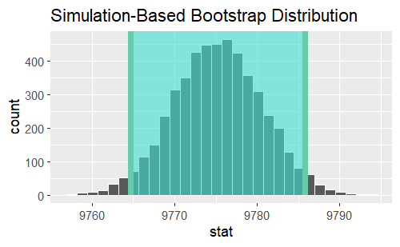

```r
infer_resample %>%
  visualise(bins = 30) +
  shade_ci(endpoints = infer_ci_95)
```

### Task 5.

You would like to know the mean(lot_area) of the sold houses with higher confidence. Calculate the 99% CI for this variable (you can re-use your bootstrap distribution from above). Is it narrower or broader than the 95% CI? Does that make sense? * broader - would get narrower if the sampling size increased.

```r
ci_99 <- bootstrap_resample_200 %>%
  summarise(
    mean = mean(mean_lot_area),
    lower_bound = quantile(mean_lot_area, probs = 0.005),
    upper_bound = quantile(mean_lot_area, probs = 0.995)
  )

ci_99
```

| mean | lower_bound | upper_bound |
| --- | --- | --- |
| 9775.219 | 8911.464 | 10891 |

```r
infer_ci_99 <- infer_resample %>%
  get_confidence_interval(level = 0.995, type = "percentile")

infer_ci_99
```

| lower_ci | upper_ci |
| --- | --- |
| 9760.205 | 9790.235 |

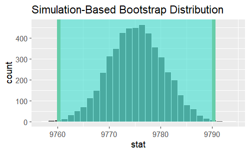

```r
infer_resample %>%
  visualise(bins = 30) +
  shade_ci(endpoints = infer_ci_99)
```

### Task 6.

Calculate the point estimate of the mean(lot_area)

```r
bootstrap_resample_200 %>%
  summarise(point_est = mean(mean_lot_area))
```

| point_est |
| --- |
| 9775.219 |

# 2 Extension

### Task 1.

Calculate a point estimate and 95% CI for the proportion of houses in the data built before 1920. Does the number of reps you use matter? [Investigate reps from 200 up to 50000, memory of your laptop permitting].